# PCA AND CLUSTERING

PCA in conjunction with k-means is a powerful method for visualizing high dimensional data. In this project, I have used National Health and Nutrition Exam Survey which has 200+ features which are only visible via dimensionality reduction. Here, I project huge number of features onto a lower-dimensional space, reduce them down to just a few important principal ones, and visualize them.

## STEP 1 -- REDUCE DIMENSIONALITY

```python
#IMPORTS
import numpy as np
import pandas as pd
import matplotlib.pyplot as plt
from sklearn.cluster import KMeans
from sklearn.decomposition import PCA
from sklearn.preprocessing import StandardScaler
%config InlineBackend.figure_format='retina'
#Load dataset
df = pd.read_csv("demographic.csv")
#Detect na and fill them with 0
df=df.fillna(0)
```

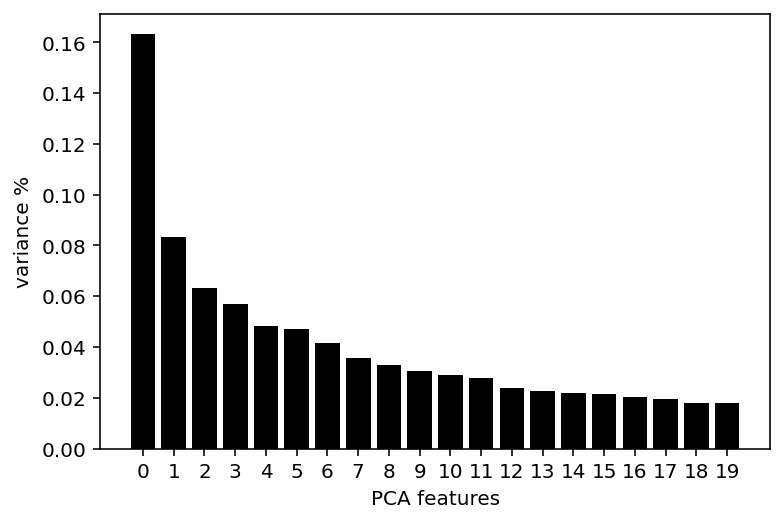

```python
#Standardize the data to have a mean of ~0 and a variance of 1
X_std = StandardScaler().fit_transform(df)

#Create a PCA instance: pca
pca = PCA(n_components=20)
principalComponents = pca.fit_transform(X_std)

#Plot the explained variances
features = range(pca.n_components_)
plt.bar(features, pca.explained_variance_ratio_, color='black')
plt.xlabel('PCA features')
plt.ylabel('variance %')
plt.xticks(features)

#Save components to a DataFrame
PCA_components = pd.DataFrame(principalComponents)
```

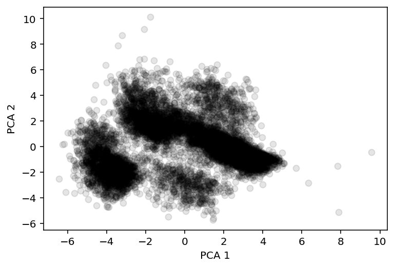

```python
plt.scatter(PCA_components[0], PCA_components[1], alpha=.1, color='black')
plt.xlabel('PCA 1')
plt.ylabel('PCA 2')
```

##### The figure above shows at least two distinguishable clusters. This factoid tells us that the observations in the dataset can be grouped. This does not show all the meaningful principal components. However, to visualize the rest of the reduced dataset with much greater granularity, we will use k-means clustering.

## STEP 2 -- CLUSTERING

##### In this step, I used k-means clustering to view the top three PCA components. Determining the ideal number of clusters for our k-means model can be done by measuring the sum of the squared distances to inertia.

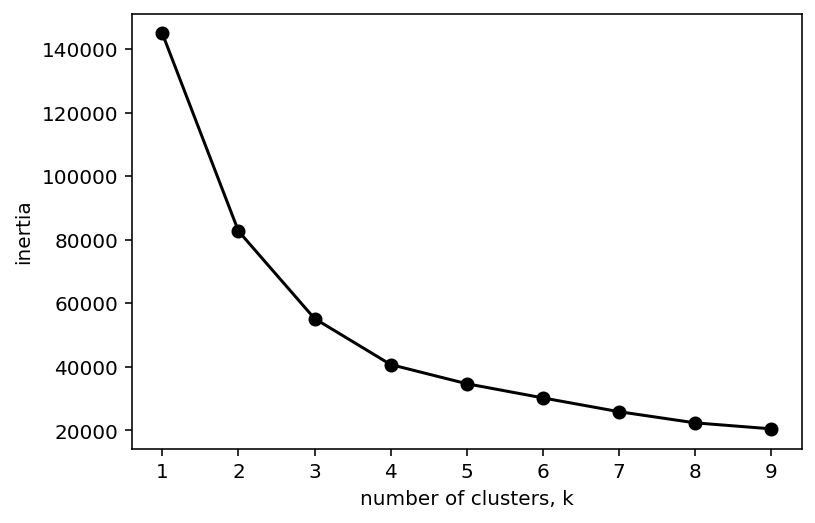

```python
ks = range(1, 10)
inertias = []
for k in ks:
    # Create a KMeans instance with k clusters: model
    model = KMeans(n_clusters=k)

    # Fit model to samples
    model.fit(PCA_components.iloc[:,:3])

    # Append the inertia to the list of inertias
    inertias.append(model.inertia_)

plt.plot(ks, inertias, '-o', color='black')
plt.xlabel('number of clusters, k')
plt.ylabel('inertia')
plt.xticks(ks)
plt.show()
```

##### This figure shows that after 4 clusters(at the elbow), the change in the value of inertia is no longer significant, and most likely, neither is the variance of the rest of the data after the elbow point. Therefore we can discard everything after k=4 and proceed to the last step in the process.

## STEP 3 -- VISUALIZATION

```python
kmeans = KMeans(n_clusters=4)
kmeans.fit(PCA_components.iloc[:,:3])
y_kmeans = kmeans.predict(PCA_components.iloc[:,:3])
```

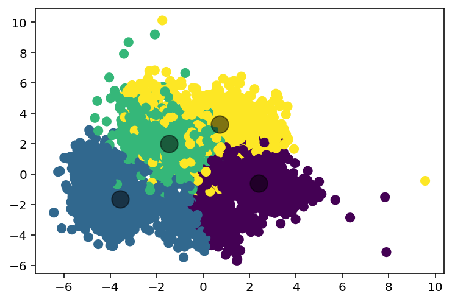

```python
plt.scatter(PCA_components[0], PCA_components[1], c=y_kmeans, s=50, cmap='viridis')
centers = kmeans.cluster_centers_
plt.scatter(centers[:, 0], centers[:, 1], c='black', s=200, alpha=0.5);
```

##### This analysis provides us the ability to notice otherwise unseen patterns and allow us to see the big picture while we pay attention to the details.